# Interpretable Machine Learning

Michael Mayer

2019-07-16

# Aims and Background of this Project

This project has three aims:

1. Provide a starting point for small to medium sized machine learning projects.
2. Explain and visualize the results of the models.
3. Automatically generate this report by a markdown script.

In contrast to classic statistical modelling techniques like linear regression, modern machine learning approaches tend to provide black box results. In some areas like visual computing or natural language processing, this is not an issue since focus usually lies on predicting things. Either the predictions are sufficiently useful in practice or the model will be discarded. However, in areas where the purpose of a statistical model is also to explain or validate underlying theories (e.g. in medicine, economics, and biology), black box models are of little use.

Thus, there is need to make machine learning models “less black” resp. to explain machine learning models as good as possible. Of special interest are **model agnostic** approaches that work for any kind of modelling technique, no matter if it is a linear regression, a neural net or a tree-based method. The only requirement is the availability of a prediction function.

Such model agnostic approaches include the following aspects:

- **Model performance**: How precise are models if applied to unseen data?
- **Variable importance**: Which variables are particularly relevant? A model agnostic way to assess this is called *permutation importance*: For each input variable $X$, its values are randomly shuffled and the drop in performance (or the increase in loss) is calculated. The more important a variable, the larger the drop. If a variable can be shuffled without any impact on model precision, it is completely irrelevant.
- **Ceteris paribus profiles**: How do predictions of line $i$ change when input $X$ is systematically being changed? E.g. how does the predicted house price change when moving the house across all ZIPs, holding all other inputs constant? For a multiple linear regression, such profiles are linear.
- **Partial dependence plots**: Average of many ceteris paribus profiles, e.g. across the validation data. Can be viewed as an average effect of variable $X$, pooled over potential intreactions.

In R, the **`DALEX` package** provides an elegant interface to many model agnostic tools. It works by creating an **explainer** consisting of a model fit, an evaluation data set, a prediction function based on the latter two, the responses, a label and an inverse link function to post-process the predictions. This is specified for each model. Based on these informations, different model agnostic evaluations can be derived and compared across models. One disadvantage of `DALEX` is its limited possibility to post-process the results. E.g. it is not easy to combine a partial dependence plot with boxplots of the response. Fortunately, it is very easy to write own functions that takes a `DALEX` explainer as input and calculates the quantities of interest. In this project, we e.g. use our own partial dependence function to stay fully flexible regarding visualization.

# Situation under Consideration

As illustration of above ideas, we use the data set `house_prices` with information on 21’613 houses sold in King County between May 2014 and May 2015. It is shipped along with R package `moderndive`.

The first few observations look as follows:

| id | date | price | bedrooms | bathrooms | sqft_living | sqft_lot | floors | waterfront | view | condition | grade | sqft_above | sqft_basement | yr_built | yr_renovated | zipcode | lat | long | sqft_living15 | sqft_lot15 |
| --- | --- | --- | --- | --- | --- | --- | --- | --- | --- | --- | --- | --- | --- | --- | --- | --- | --- | --- | --- | --- |
| 7129300520 | 2014-10-13 | 221900 | 3 | 1.00 | 1180 | 5650 | 1 | FALSE | 0 | 3 | 7 | 1180 | 0 | 1955 | 0 | 98178 | 47.5112 | -122.257 | 1340 | 5650 |
| 6414100192 | 2014-12-09 | 538000 | 3 | 2.25 | 2570 | 7242 | 2 | FALSE | 0 | 3 | 7 | 2170 | 400 | 1951 | 1991 | 98125 | 47.7210 | -122.319 | 1690 | 7639 |
| 5631500400 | 2015-02-25 | 180000 | 2 | 1.00 | 770 | 10000 | 1 | FALSE | 0 | 3 | 6 | 770 | 0 | 1933 | 0 | 98028 | 47.7379 | -122.233 | 2720 | 8062 |
| 2487200875 | 2014-12-09 | 604000 | 4 | 3.00 | 1960 | 5000 | 1 | FALSE | 0 | 5 | 7 | 1050 | 910 | 1965 | 0 | 98136 | 47.5208 | -122.393 | 1360 | 5000 |
| 1954400510 | 2015-02-18 | 510000 | 3 | 2.00 | 1680 | 8080 | 1 | FALSE | 0 | 3 | 8 | 1680 | 0 | 1987 | 0 | 98074 | 47.6168 | -122.045 | 1800 | 7503 |
| 7237550310 | 2014-05-12 | 1225000 | 4 | 4.50 | 5420 | 101930 | 1 | FALSE | 0 | 3 | 11 | 3890 | 1530 | 2001 | 0 | 98053 | 47.6561 | -122.005 | 4760 | 101930 |

Thus we have access to many relevant infos like size, condition as well as location of the objects. We want to use these variables to predict the (log) house prices by the help of the following regression techniques and shed some light on them:

- linear regression,
- random forests, and
- boosted trees.

We use 70% of the data to calculate the models, 20% for evaluating their performance and for explaining them. 10% we keep untouched.

*Note:* All model related decisions were made on the training data, e.g. by five-fold cross-validation in case of the parameter tuning of the boosted trees.

**Monotonicity**: One big step towards explainability of a model is to set monotonicity constraints on the model effects, an option that is e.g. available in the two major tree boosting libraries “XGBoost” and “LightGBM” (we are working with the latter here). For our tree booster, we impose positive constraints on “grade”, “sqft_living”, “condition” as well as “waterfront”. As a consequence, its ceteris paribus profiles and their aggregated partial dependence plots will be monotonically increasing in these variables. So e.g. a higher grade will never lead to a lower prediction if all other values are kept constant. This is an extremely important option in real-world application where users of the model can play around with the input.

# Results

We now briefly summarize the results of the models.

## Performance of the Models

The model performances on the 20% validation data (evaluated on log-currency scale) is as follows.

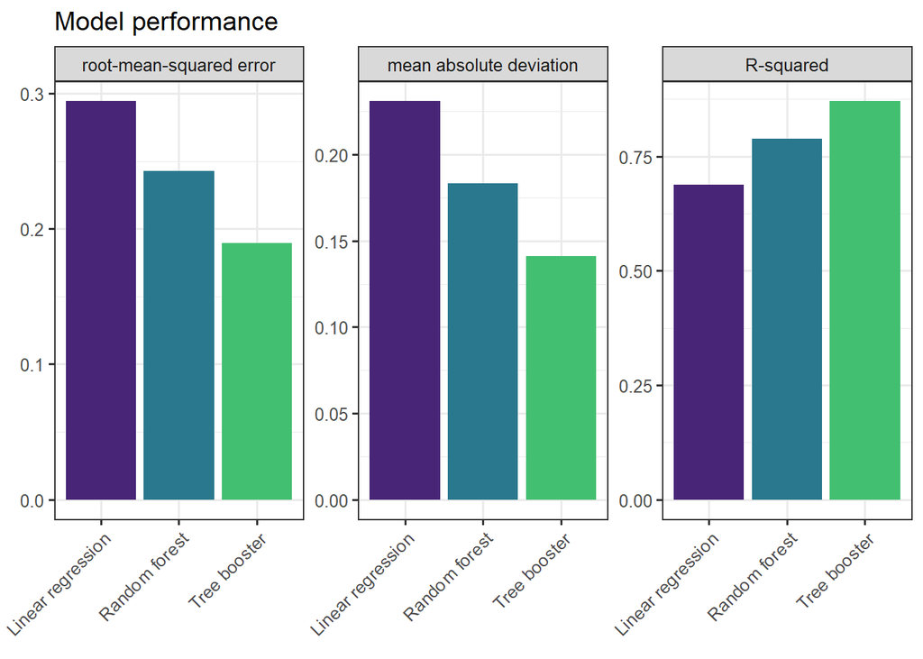

The winner is the tuned tree booster.

## Variable Importance

Which variables have the highest impact on the response? Which ones are irrelevant?

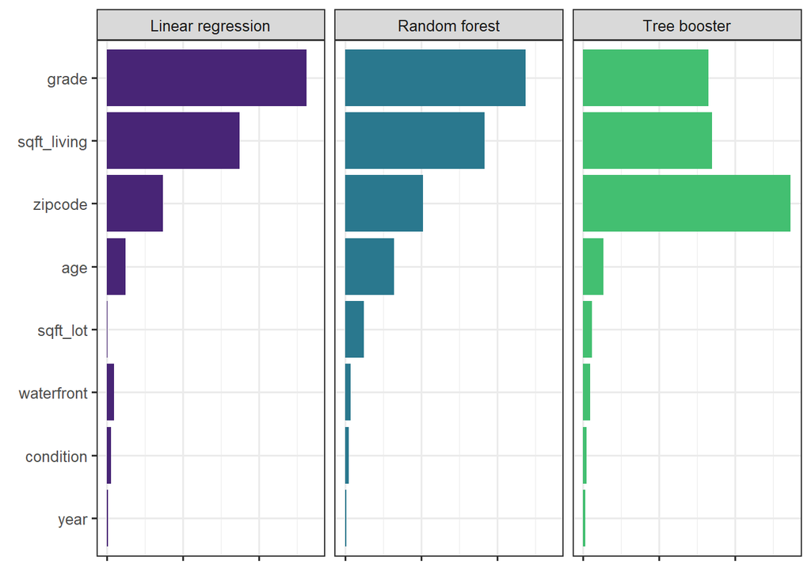

The best predictors seem to be grade, sqft_living, and zipcode. It is interesting to see how well the boosted trees pick up the effect of the zip code, even if we have represented it simply as a numeric variable without dummy coding or pre-sorting on the response.

## Effects

We now describe the association with the response for each input variable by considering both

- empirical effects, i.e. boxplots (boxes only) of the response per level of the covariable,
- corresponding partial dependence plots of modelled effects, i.e. averaged ceteris paribus profiles across the validation data set.

The results are ordered by variable importance.

*Note:* Numeric input variables with many distinct values were binned for visualization.

**Important: The partial dependence plot do not show average predictions, but average ceteris paribus profiles, i.e. partial effects that cannot be explained by other factors.**

### grade

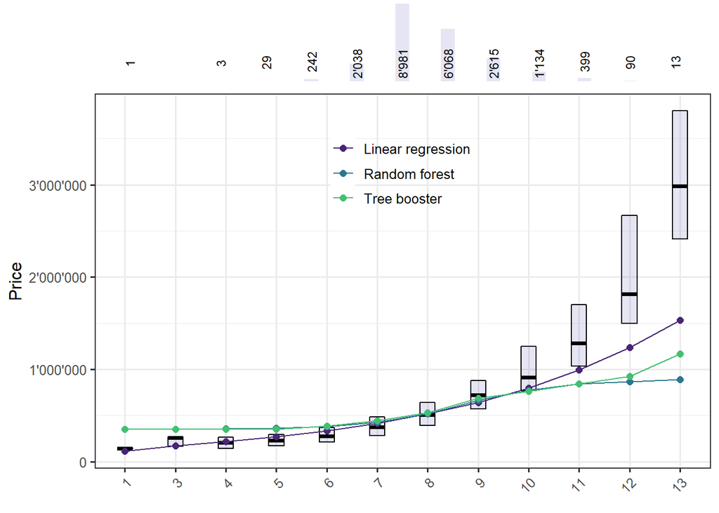

### sqft_living

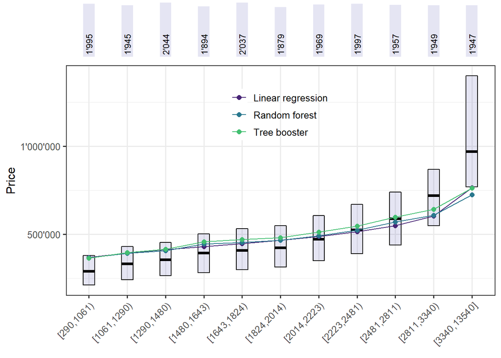

### zipcode

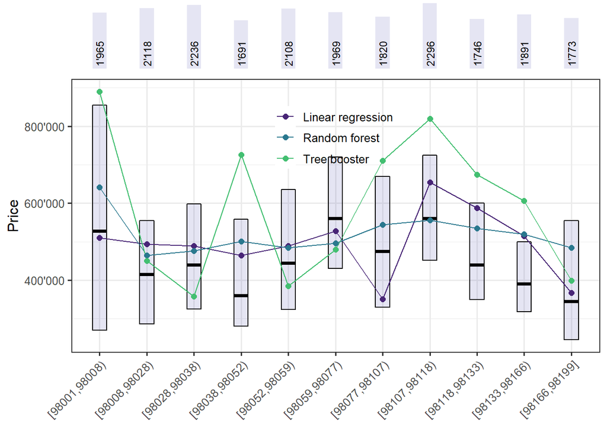

### age

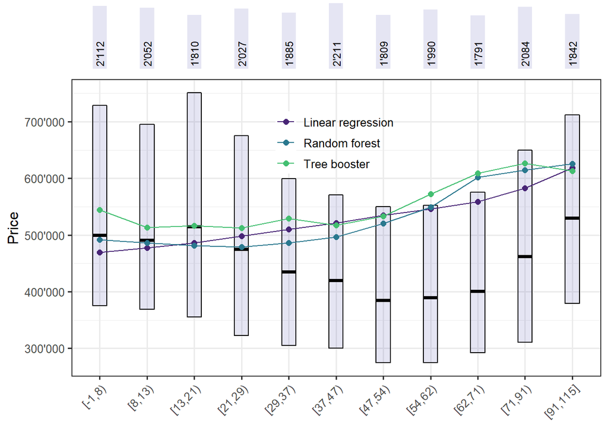

### sqft_lot

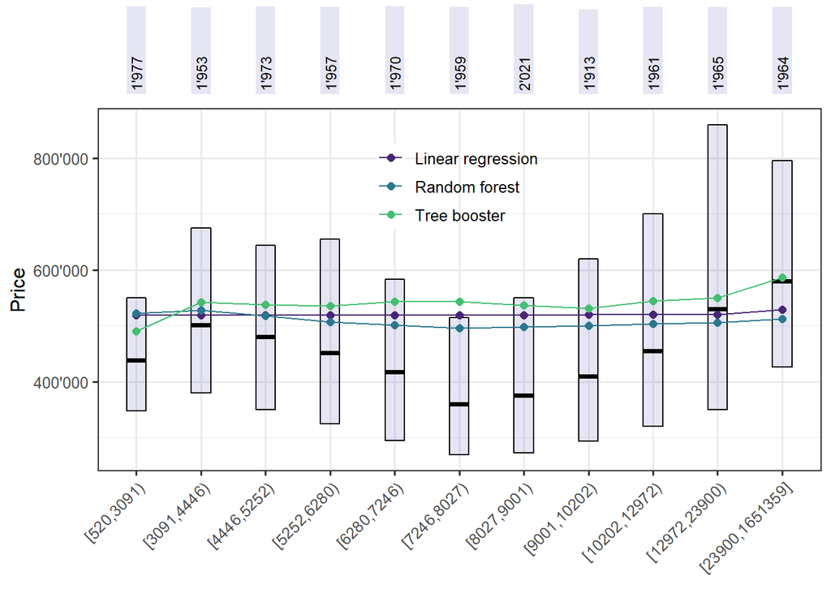

### waterfront

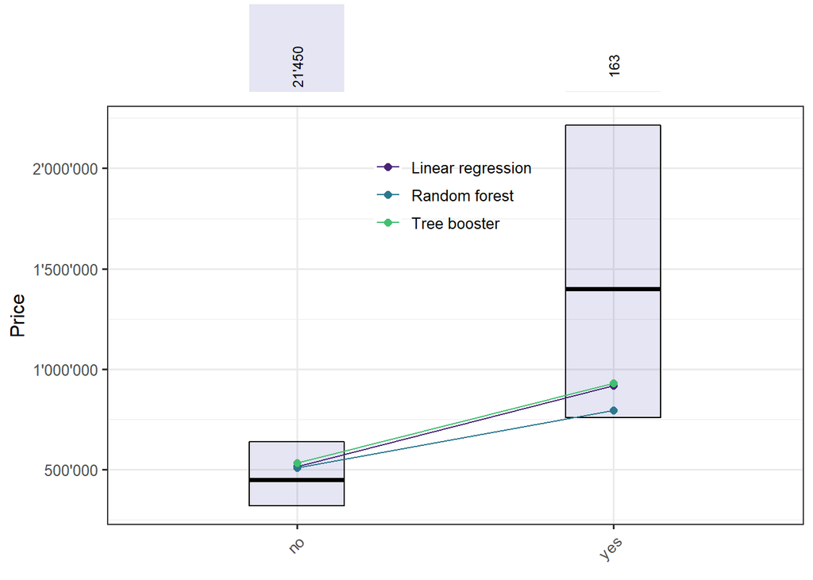

### condition

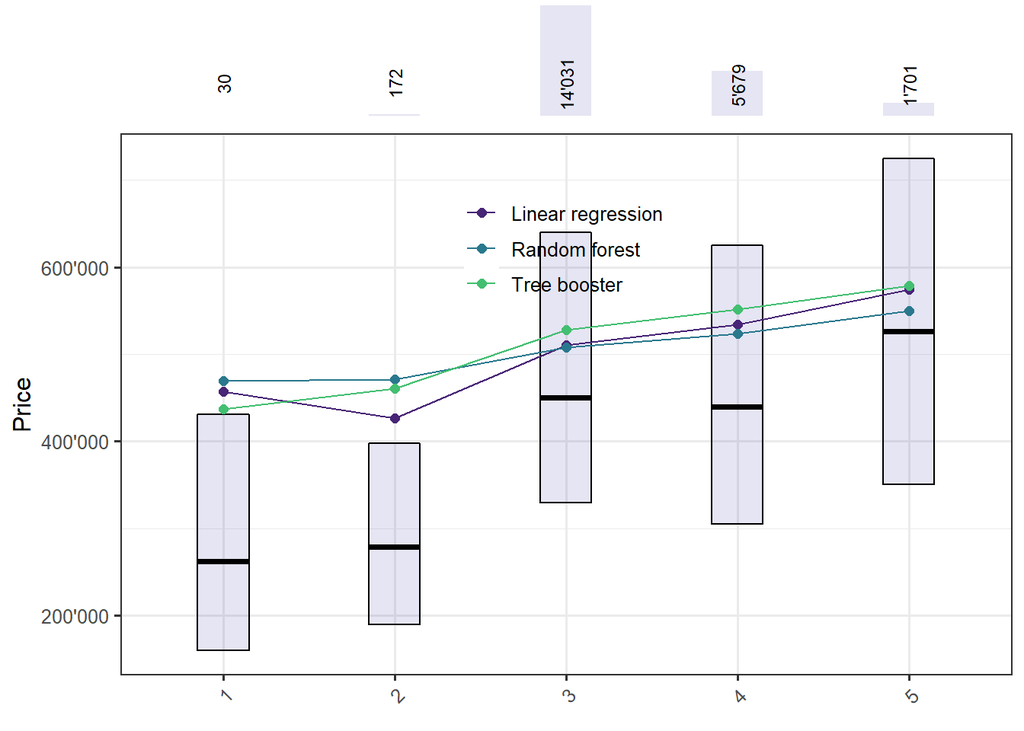

### year

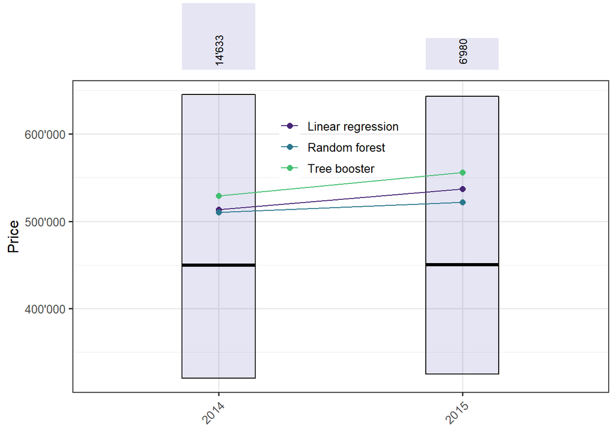